# R Notebook

#### Importing Data Science Package via Tidyverse

```r
library(tidyverse)
```

#### 1. Write a multiplication script using either a “for” loop or a “while” loop. Show your script.

(5 points)

```r
for (i in 0:5) {
  print(i*2)
}
```

```
[1] 0
[1] 2
[1] 4
[1] 6
[1] 8
[1] 10
```

##### The following script uses a for loop to loop from 0 to 5 and print the current value multipled by two.

#### 2 Using the customers data (custdata.tsv). Like histogram, you can also plot the density of a variable.

```r
customerFP = 'Data/custdata.tsv'
customerDF = read.table(file = customerFP, sep = '\t', header = TRUE)
```

#### 2.1: Figure out how to plot density of income. (5 points)

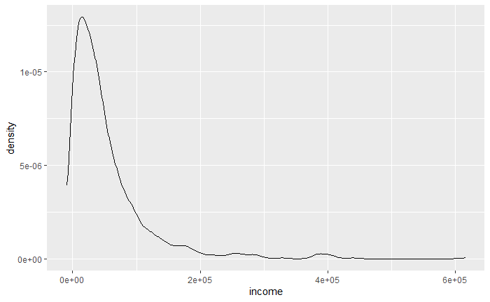

```r
ggplot(customerDF, aes(x=income)) + geom_density()
```

#### 2.2: Provide a couple of sentences of description along with the plot. Imagine you are explaining this to your manager or a senior leader. (5 points)

##### The following graph is right skewed meaning that a high portion of customers from the data set have low income. As income increases the amount of customers drastically decreases, meaning a majority of customers contained in this data set are of the low income type.

#### 3.1: Create a bar chart for housing type using the customers data. Make sure to remove the “NA” type. [Hint: You can use subset function with an appropriate condition on housing type field.] Provide your commands and the plot.(5 points)

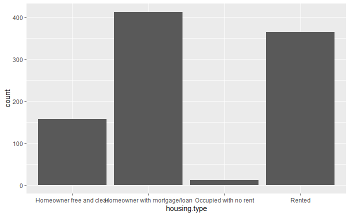

```r
subsetHousingType = customerDF[complete.cases(customerDF[ , 7]),]
ggplot(subsetHousingType) + geom_bar(aes(x=housing.type))
```

##### Subsetted data using complete.cases to remove NA values. From the graph it can be seen that homeowners with mortgage/loan and Rented have the highest counts.

#### 4.1: Extract a subset of customers that are married and have an income more than $50,000. (5 points)

```r
marriedByIncome = subset(customerDF, marital.stat == "Married" & income > 50000)
marriedByIncome
```

|  | custid | sex | is.employed | income | marital.stat | health.ins | housing.type | recent.move | num.vehicles | age | state.of.res |
| --- | --- | --- | --- | --- | --- | --- | --- | --- | --- | --- | --- |
| 12 | 17134 | M | TRUE | 220000 | Married | TRUE | Homeowner free and clear | TRUE | 2 | 33.0000 | Indiana |
| 24 | 30768 | M | TRUE | 80000 | Married | TRUE | Homeowner with mortgage/loan | FALSE | 2 | 50.0000 | New Jersey |
| 41 | 52197 | M | NA | 65100 | Married | TRUE | Homeowner free and clear | FALSE | 2 | 66.0000 | Florida |
| 44 | 52436 | F | TRUE | 139000 | Married | TRUE | Homeowner with mortgage/loan | FALSE | 2 | 46.0000 | Pennsylvania |
| 46 | 53214 | M | TRUE | 84010 | Married | TRUE | Homeowner with mortgage/loan | FALSE | 2 | 57.0000 | New York |
| 48 | 54177 | M | FALSE | 51500 | Married | TRUE | Homeowner free and clear | FALSE | 2 | 86.0000 | New York |
| 52 | 62999 | M | TRUE | 91000 | Married | TRUE | Homeowner with mortgage/loan | FALSE | 4 | 51.0000 | New York |
| 55 | 67776 | M | TRUE | 52000 | Married | TRUE | Homeowner with mortgage/loan | FALSE | 1 | 38.0000 | Florida |
| 57 | 68221 | M | TRUE | 78000 | Married | TRUE | Homeowner with mortgage/loan | FALSE | 2 | 29.0000 | California |
| 58 | 69062 | M | TRUE | 120300 | Married | TRUE | Homeowner free and clear | FALSE | 4 | 59.0000 | California |

[output cut: 206 more lines]

##### Subsetted data to only include married couple who earn more than 50000.

#### 4.2: What percentage of these customers have health insurance? (5 points)

```r
marriedByIncome %>%
  group_by(health.ins) %>%
  summarise(percent = round(100 * n()/nrow(marriedByIncome),digits = 2))
```

| health.ins | percent |
| --- | --- |
| FALSE | 3.7 |
| TRUE | 96.3 |

##### Based on the results 96.3% of the married couples have health insurance.

#### 4.3: How does this percentage differ from that for the whole data set? (5 points)

```r
customerDF %>%
  group_by(health.ins) %>%
  summarise(percent = round(100 * n()/nrow(customerDF),digits = 2))
```

| health.ins | percent |
| --- | --- |
| FALSE | 15.9 |
| TRUE | 84.1 |

#### 5.2: Report your correlation numbers and interpretations. [Hint: Make sure to remove invalid data points, otherwise you may get incorrect answers!] (10 points)

```r
subsetByAge = filter(customerDF, age <= 88 & age >= 18 & income >= 1000 & !is.na(num.vehicles))

round(cor(subsetByAge[,c("age","income","num.vehicles")]),digits = 2)
```

```
               age income num.vehicles
age           1.00  -0.01        -0.05
income       -0.01   1.00         0.15
num.vehicles -0.05   0.15         1.00
```

#### 6. You are given a data file containing observations for dating. Someone who dated 1000 people (!) recorded data about how much that person travels (Miles), plays games (Games, and eats ice cream (Icecream). With this, the decision about that person (Like) is also noted. Use this data to answer the following questions using R:

#### 6.1: Is there a relationship between eating ice cream and playing games? What about traveling and playing games? Report correlation values for these and comment on them. (10 points)

```r
datingFP = 'Data/dating.csv'
datingDF = read.table(file = datingFP, sep = ',', header = TRUE)

round(cor(datingDF[,c("Games","Miles","Icecream")]),digits = 2)
```

```
         Games Miles Icecream
Games     1.00  0.47     0.01
Miles     0.47  1.00    -0.01
Icecream  0.01 -0.01     1.00
```

##### A slight positive correlation can be seen between Games and Miles, and no correlation can be seen between eating ice cream and playing games.

```r
filteredData = filter(datingDF, Games >= 1)
```

#### 6.2: Let us use Miles to predict Games. Perform regression using Miles as the predictor and Games as the response variable. Show the regression graph with the regression line. Write the line equation. (10 points)

```r
summary(filteredData)
```

```
     Miles           Games           Icecream            Like
 Min.   :    0   Min.   : 1.020   Min.   :0.001156   Length:891
 1st Qu.:16829   1st Qu.: 3.729   1st Qu.:0.414531   Class :character
 Median :34068   Median : 7.601   Median :0.819419   Mode  :character
 Mean   :35830   Mean   : 7.338   Mean   :0.836403
 3rd Qu.:51315   3rd Qu.:10.263   3rd Qu.:1.281495
 Max.   :91273   Max.   :20.919   Max.   :1.695517
```

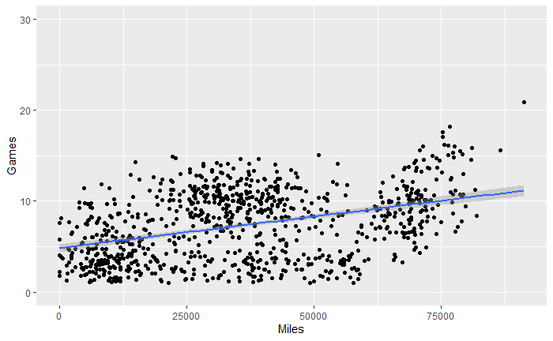

```r
# y = ax + b --> x=predictor=Miles, y=response=Games
ggplot(filteredData, aes(x=Miles,y=Games)) + geom_point() +
  stat_smooth(method = 'lm') + ylim(0,30)
```

```r
lm(Games~Miles, data = filteredData)
```

```
Call:
lm(formula = Games ~ Miles, data = filteredData)

Coefficients:
(Intercept)        Miles
  4.863e+00    6.909e-05
```

#### 6.3: Now let us see how well we can cluster the data based on the outcome (Like). Use Miles and Games to plot the data and color the points using Like. Now cluster the data using k-means and plot the same data using clustering information. Show the plot and compare it with the previous plot. Provide your thoughts about how well your clustering worked in two to four sentences. (10 points)

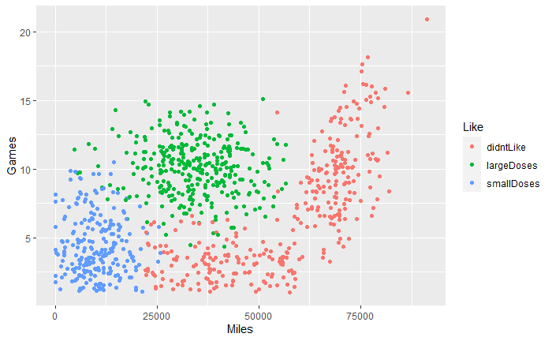

```r
ggplot(filteredData, aes(x=Miles,y=Games, color = Like)) + geom_point()
```

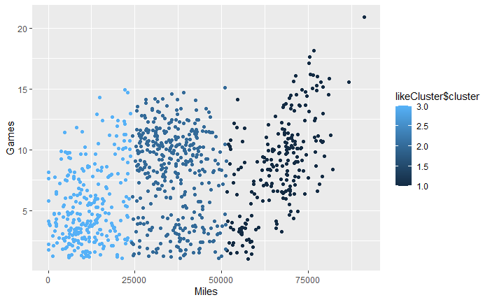

```r
set.seed(20)
likeCluster = kmeans(filteredData[,1:2],3, nstart = 20)
ggplot(filteredData, aes(x=Miles,y=Games, color =  likeCluster$cluster)) + geom_point()
```